# Project Title: ML Graded Microproject on Employee Attrition Prediction

## Developer Name - Anuj Rastogi

## Introduction

Welcome to my graded microproject on employee attrition prediction! In this assignment, I aim to analyze the HR Dataset to uncover insights about possible employee attrition within the organization.

### Problem Statement:

The objective of this microproject is to build appropriate machine learning models to predict employee attrition and provide valuable insights to the organization. Specifically, I'll address the following questions along the way:

- Which variables are significant in predicting employee attrition?
- How well do those variables describe the likelihood of attrition?

## Project Information

The organization, ABC Corporation, is facing challenges related to employee attrition and wants to better understand the factors influencing attrition rates. By analyzing the provided HR dataset, the organization aims to identify potential areas for improvement in employee retention strategies.

### Date of Completion:

- 26th March 2024

### Data Source:

The dataset used in this microproject is obtained from [GitHub](https://github.com/anujR1994/Data-Science-Projects) and contains information about employee attributes and their attrition status.

## About the Dataset

The HR dataset contains various features related to employees' demographics, job satisfaction, and work environment. Here are some of the key features included in the dataset:

1. **Education:** Level of education attained by the employee
2. **Environment Satisfaction:** Satisfaction level with the work environment
3. **Job Involvement:** Level of involvement in job-related activities
4. **Job Satisfaction:** Level of satisfaction with the job role
5. **Performance Rating:** Performance rating received by the employee
6. **Relationship Satisfaction:** Satisfaction level with work relationships
7. **Work Life Balance:** Rating of work-life balance experienced by the employee

## Methodology

1. **Data Preprocessing:** Cleaning the data, handling missing values, and encoding categorical variables.
2. **Exploratory Data Analysis:** Understanding the distribution of features and identifying correlations with attrition.
3. **Model Development:** Training machine learning models to predict employee attrition.
4. **Model Evaluation:** Assessing model performance using metrics such as accuracy, precision, recall, and F1-score.
5. **Conclusion:** Summarizing findings and providing recommendations based on the analysis.

**Data Preparation, Visualization, and Exploratory Data Analysis:**

Let's dive into the microproject and start uncovering insights about employee attrition!

```python
# Import necessary libraries
import pandas as pd
import numpy as np
import seaborn as sns
import matplotlib.pyplot as plt
```

```python
# Load the dataset
path = '/Users/anujrastogi/Library/CloudStorage/OneDrive-Personal/Desktop/Assignments & Projects/ML-Graded%20Internal%20Microproject/HR_DATASET.csv'

# Load the dataset
df = pd.read_csv(path)
```

```python
df.head()
```

|  | Age | Attrition | BusinessTravel | DailyRate | Department | DistanceFromHome | Education | EducationField | EmployeeCount | EmployeeNumber | ... | RelationshipSatisfaction | StandardHours | StockOptionLevel | TotalWorkingYears | TrainingTimesLastYear | WorkLifeBalance | YearsAtCompany | YearsInCurrentRole | YearsSinceLastPromotion | YearsWithCurrManager |
| --- | --- | --- | --- | --- | --- | --- | --- | --- | --- | --- | --- | --- | --- | --- | --- | --- | --- | --- | --- | --- | --- |
| 0 | 41 | Yes | Travel_Rarely | 1102 | Sales | 1 | 2 | Life Sciences | 1 | 1 | ... | 1 | 80 | 0 | 8 | 0 | 1 | 6 | 4 | 0 | 5 |
| 1 | 49 | No | Travel_Frequently | 279 | Research & Development | 8 | 1 | Life Sciences | 1 | 2 | ... | 4 | 80 | 1 | 10 | 3 | 3 | 10 | 7 | 1 | 7 |
| 2 | 37 | Yes | Travel_Rarely | 1373 | Research & Development | 2 | 2 | Other | 1 | 4 | ... | 2 | 80 | 0 | 7 | 3 | 3 | 0 | 0 | 0 | 0 |
| 3 | 33 | No | Travel_Frequently | 1392 | Research & Development | 3 | 4 | Life Sciences | 1 | 5 | ... | 3 | 80 | 0 | 8 | 3 | 3 | 8 | 7 | 3 | 0 |
| 4 | 27 | No | Travel_Rarely | 591 | Research & Development | 2 | 1 | Medical | 1 | 7 | ... | 4 | 80 | 1 | 6 | 3 | 3 | 2 | 2 | 2 | 2 |

5 rows × 35 columns

```python
#checking info of dataset

df.info()
```

```
<class 'pandas.core.frame.DataFrame'>
RangeIndex: 917 entries, 0 to 916
Data columns (total 35 columns):
 #   Column                    Non-Null Count  Dtype
---  ------                    --------------  -----
 0   Age                       917 non-null    int64
 1   Attrition                 917 non-null    object
 2   BusinessTravel            917 non-null    object
 3   DailyRate                 917 non-null    int64
 4   Department                917 non-null    object
 5   DistanceFromHome          917 non-null    int64
 6   Education                 917 non-null    int64
 7   EducationField            917 non-null    object
 8   EmployeeCount             917 non-null    int64
 9   EmployeeNumber            917 non-null    int64
```

[output cut: 27 more lines]

```python
# Summary statistics of numerical feature
df.describe().T
```

|  | count | mean | std | min | 25% | 50% | 75% | max |
| --- | --- | --- | --- | --- | --- | --- | --- | --- |
| Age | 917.0 | 36.938931 | 8.984981 | 18.0 | 30.0 | 36.0 | 43.0 | 60.0 |
| DailyRate | 917.0 | 785.711014 | 401.902148 | 102.0 | 444.0 | 772.0 | 1141.0 | 1498.0 |
| DistanceFromHome | 917.0 | 9.294438 | 8.092566 | 1.0 | 2.0 | 7.0 | 14.0 | 29.0 |
| Education | 917.0 | 2.921483 | 1.020717 | 1.0 | 2.0 | 3.0 | 4.0 | 5.0 |
| EmployeeCount | 917.0 | 1.000000 | 0.000000 | 1.0 | 1.0 | 1.0 | 1.0 | 1.0 |
| EmployeeNumber | 917.0 | 1413.466739 | 388.606884 | 1.0 | 1084.0 | 1425.0 | 1737.0 | 2068.0 |
| EnvironmentSatisfaction | 917.0 | 2.738277 | 1.103382 | 1.0 | 2.0 | 3.0 | 4.0 | 4.0 |
| HourlyRate | 917.0 | 66.231189 | 20.237536 | 30.0 | 49.0 | 66.0 | 84.0 | 100.0 |
| JobInvolvement | 917.0 | 2.721919 | 0.720936 | 1.0 | 2.0 | 3.0 | 3.0 | 4.0 |
| JobLevel | 917.0 | 2.044711 | 1.100400 | 1.0 | 1.0 | 2.0 | 3.0 | 5.0 |
| JobSatisfaction | 917.0 | 2.688113 | 1.110097 | 1.0 | 2.0 | 3.0 | 4.0 | 4.0 |
| MonthlyIncome | 917.0 | 6452.293348 | 4685.137761 | 1051.0 | 2933.0 | 4877.0 | 8103.0 | 19973.0 |
| MonthlyRate | 917.0 | 14428.468920 | 7188.332799 | 2097.0 | 8018.0 | 14255.0 | 20763.0 | 26997.0 |
| NumCompaniesWorked | 917.0 | 2.696838 | 2.489217 | 0.0 | 1.0 | 2.0 | 4.0 | 9.0 |
| PercentSalaryHike | 917.0 | 15.214831 | 3.640007 | 11.0 | 12.0 | 14.0 | 18.0 | 25.0 |
| PerformanceRating | 917.0 | 3.149400 | 0.356677 | 3.0 | 3.0 | 3.0 | 3.0 | 4.0 |
| RelationshipSatisfaction | 917.0 | 2.637950 | 1.078673 | 1.0 | 2.0 | 3.0 | 4.0 | 4.0 |
| StandardHours | 917.0 | 80.000000 | 0.000000 | 80.0 | 80.0 | 80.0 | 80.0 | 80.0 |
| StockOptionLevel | 917.0 | 0.821156 | 0.864555 | 0.0 | 0.0 | 1.0 | 1.0 | 3.0 |
| TotalWorkingYears | 917.0 | 11.179935 | 7.802790 | 0.0 | 6.0 | 10.0 | 15.0 | 40.0 |
| TrainingTimesLastYear | 917.0 | 2.791712 | 1.292917 | 0.0 | 2.0 | 3.0 | 3.0 | 6.0 |
| WorkLifeBalance | 917.0 | 2.760087 | 0.708047 | 1.0 | 2.0 | 3.0 | 3.0 | 4.0 |
| YearsAtCompany | 917.0 | 6.972737 | 5.951250 | 0.0 | 3.0 | 5.0 | 9.0 | 36.0 |
| YearsInCurrentRole | 917.0 | 4.217012 | 3.588223 | 0.0 | 2.0 | 3.0 | 7.0 | 17.0 |
| YearsSinceLastPromotion | 917.0 | 2.147219 | 3.176250 | 0.0 | 0.0 | 1.0 | 3.0 | 15.0 |
| YearsWithCurrManager | 917.0 | 4.062159 | 3.571395 | 0.0 | 2.0 | 3.0 | 7.0 | 17.0 |

```python
# summary of categorical data

df.describe(include=['object'])
```

|  | Attrition | BusinessTravel | Department | EducationField | Gender | JobRole | MaritalStatus | Over18 | OverTime |
| --- | --- | --- | --- | --- | --- | --- | --- | --- | --- |
| count | 917 | 917 | 917 | 917 | 917 | 917 | 917 | 917 | 917 |
| unique | 2 | 3 | 3 | 6 | 2 | 9 | 3 | 1 | 2 |
| top | No | Travel_Rarely | Research & Development | Life Sciences | Male | Sales Executive | Married | Y | No |
| freq | 763 | 648 | 597 | 385 | 550 | 203 | 436 | 917 | 656 |

```python
# Check for missing value
df.isnull().sum()
```

```
Age                         0
Attrition                   0
BusinessTravel              0
DailyRate                   0
Department                  0
DistanceFromHome            0
Education                   0
EducationField              0
EmployeeCount               0
EmployeeNumber              0
EnvironmentSatisfaction     0
Gender                      0
HourlyRate                  0
JobInvolvement              0
JobLevel                    0
JobRole                     0
JobSatisfaction             0
MaritalStatus               0
MonthlyIncome               0
MonthlyRate                 0
NumCompaniesWorked          0
Over18                      0
OverTime                    0
PercentSalaryHike           0
PerformanceRating           0
RelationshipSatisfaction    0
StandardHours               0
StockOptionLevel            0
TotalWorkingYears           0
TrainingTimesLastYear       0
WorkLifeBalance             0
YearsAtCompany              0
YearsInCurrentRole          0
YearsSinceLastPromotion     0
YearsWithCurrManager        0
dtype: int64
```

```python
# checking for duplicates

df.duplicated().sum()
```

```
0
```

```python
# target variable is Attrition-----> counting its value

df.Attrition.value_counts()
```

```
Attrition
No     763
Yes    154
Name: count, dtype: int64
```

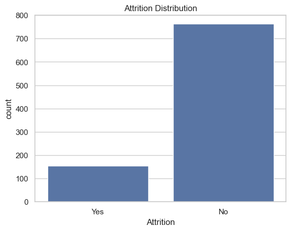

```python
# Visualize distribution of the target variable 'Attrition'
sns.countplot(x='Attrition', data=df)
plt.title('Attrition Distribution')
plt.show()
```

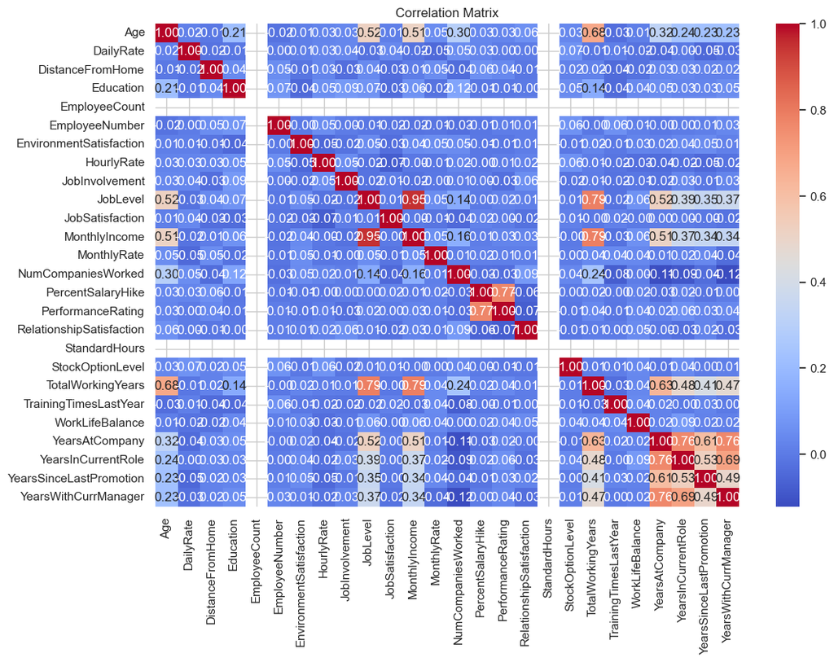

```python
# Exclude non-numeric columns from the DataFrame
numeric_df = df.select_dtypes(include=['int64', 'float64'])

# Visualize correlation matrix
plt.figure(figsize=(12, 8))
sns.heatmap(numeric_df.corr(), annot=True, cmap='coolwarm', fmt=".2f")
plt.title('Correlation Matrix')
plt.show()
```

```python
# counting all Attrition Rate


attrition_count = df['Attrition'].value_counts()['Yes']
total_employees = len(df)
overall_attrition_rate = (attrition_count / total_employees) * 100
print("Overall Attrition Rate: {:.2f}%".format(overall_attrition_rate))

# Attrition Rates Across Different Categories
categories = ['Department', 'EducationField', 'BusinessTravel']

for category in categories:
    attrition_rates = df.groupby(category)['Attrition'].value_counts(normalize=True).unstack()
    print("\nAttrition Rates Across", category)
    print(attrition_rates * 100)
```

```
Overall Attrition Rate: 16.79%

Attrition Rates Across Department
Attrition                      No        Yes
Department
Human Resources         82.222222  17.777778
Research & Development  85.762144  14.237856
Sales                   77.818182  22.181818

Attrition Rates Across EducationField
Attrition                No        Yes
EducationField
Human Resources   72.222222  27.777778
Life Sciences     84.155844  15.844156
Marketing         77.173913  22.826087
Medical           85.614035  14.385965
Other             83.636364  16.363636
Technical Degree  79.268293  20.731707

Attrition Rates Across BusinessTravel
Attrition                 No        Yes
BusinessTravel
Non-Travel         90.721649   9.278351
Travel_Frequently  74.418605  25.581395
Travel_Rarely      84.413580  15.586420
```

```python
# 2. Demographic Analysis
mean_age_left = df[df['Attrition'] == 'Yes']['Age'].mean()
mean_age_stayed = df[df['Attrition'] == 'No']['Age'].mean()
print("\nMean Age of Employees Who Left:", mean_age_left)
print("Mean Age of Employees Who Stayed:", mean_age_stayed)
```

```
Mean Age of Employees Who Left: 34.3051948051948
Mean Age of Employees Who Stayed: 37.470511140235914
```

```python
# 3. Job Satisfaction and Work-Life Balance
job_satisfaction_attrition = df.groupby('JobSatisfaction')['Attrition'].value_counts(normalize=True).unstack()
print("Job Satisfaction vs Attrition:")
print(job_satisfaction_attrition * 100)

# Replacing 'WorkLifeBalance' with the correct column name 'WorkLifeBalance'
life_balance_attrition = df.groupby('WorkLifeBalance')['Attrition'].value_counts(normalize=True).unstack()
print("Work Life Balance vs Attrition:")
print(life_balance_attrition * 100)
```

```
Job Satisfaction vs Attrition:
Attrition               No        Yes
JobSatisfaction
1                75.392670  24.607330
2                81.564246  18.435754
3                85.294118  14.705882
4                87.636364  12.363636
Work Life Balance vs Attrition:
Attrition               No        Yes
WorkLifeBalance
1                61.224490  38.775510
2                83.561644  16.438356
3                85.326087  14.673913
4                81.443299  18.556701
```

```python
# Business Travel Frequency

travel_attrition = df.groupby('BusinessTravel')['Attrition'].value_counts(normalize=True).unstack()
print("Business Travel vs Attrition:")
print(travel_attrition * 100)
```

```
Business Travel vs Attrition:
Attrition                 No        Yes
BusinessTravel
Non-Travel         90.721649   9.278351
Travel_Frequently  74.418605  25.581395
Travel_Rarely      84.413580  15.586420
```

```python
# 6. Performance and Training
performance_attrition = df.groupby('PerformanceRating')['Attrition'].value_counts(normalize=True).unstack()
print("Performance Rating vs Attrition:")
print(performance_attrition * 100)

training_attrition = df.groupby('TrainingTimesLastYear')['Attrition'].value_counts(normalize=True).unstack()
print("Training Times Last Year vs Attrition:")
print(training_attrition * 100)
```

```
Performance Rating vs Attrition:
Attrition                 No        Yes
PerformanceRating
3                  83.333333  16.666667
4                  82.481752  17.518248
Training Times Last Year vs Attrition:
Attrition                     No        Yes
TrainingTimesLastYear
0                      72.972973  27.027027
1                      84.615385  15.384615
2                      80.174927  19.825073
3                      84.887460  15.112540
4                      79.487179  20.512821
5                      95.312500   4.687500
6                      91.111111   8.888889
```

```python
# Distance from Home

distance_attrition = df.groupby(pd.cut(df['DistanceFromHome'], bins=5))['Attrition'].value_counts(normalize=True).unstack()
print("Distance From Home vs Attrition:")
print(distance_attrition * 100)
```

```
Distance From Home vs Attrition:
Attrition                No        Yes
DistanceFromHome
(0.972, 6.6]      86.231884  13.768116
(6.6, 12.2]       82.730924  17.269076
(12.2, 17.8]      76.470588  23.529412
(17.8, 23.4]      82.278481  17.721519
(23.4, 29.0]      77.777778  22.222222
```

## Visualizing with Attrition Rate

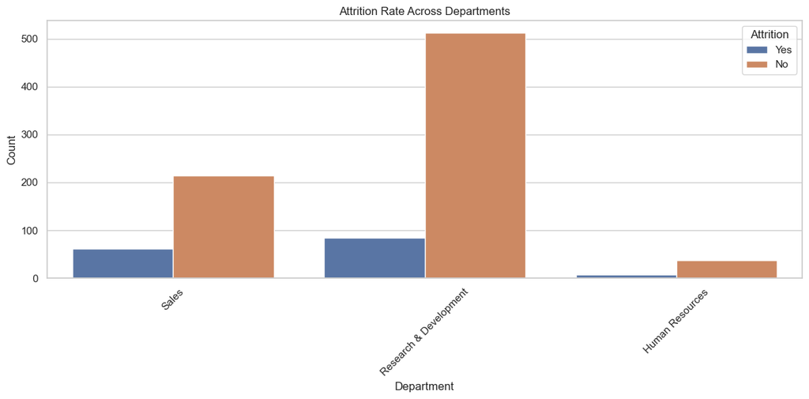

```python
# Set Seaborn style
sns.set(style="whitegrid")

# Attrition Rate: Bar chart
plt.figure(figsize=(12, 6))
sns.countplot(x='Department', hue='Attrition', data=df)
plt.title('Attrition Rate Across Departments')
plt.xlabel('Department')
plt.ylabel('Count')
plt.xticks(rotation=45)
plt.legend(title='Attrition', loc='upper right')
plt.tight_layout()
plt.show()
```

```
No artists with labels found to put in legend.  Note that artists whose label start with an underscore are ignored when legend() is called with no argument.
```

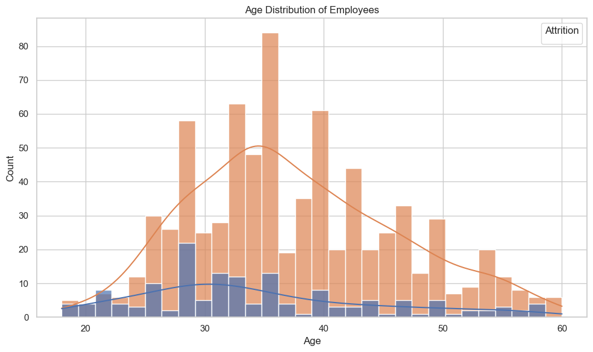

```python
# Demographic Analysis: Histograms of Age
plt.figure(figsize=(10, 6))
sns.histplot(data=df, x='Age', hue='Attrition', bins=30, kde=True, alpha=0.7)
plt.title('Age Distribution of Employees')
plt.xlabel('Age')
plt.ylabel('Count')
plt.legend(title='Attrition', loc='upper right')
plt.tight_layout()
plt.show()
```

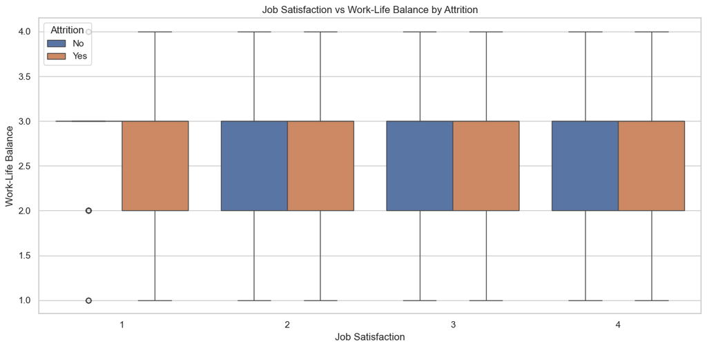

```python
# Job Satisfaction and Work-Life Balance: Box plots

plt.figure(figsize=(12, 6))
sns.boxplot(x='JobSatisfaction', y='WorkLifeBalance', hue='Attrition', data=df)
plt.title('Job Satisfaction vs Work-Life Balance by Attrition')
plt.xlabel('Job Satisfaction')
plt.ylabel('Work-Life Balance')
plt.legend(title='Attrition', loc='upper left')
plt.tight_layout()
plt.show()
```

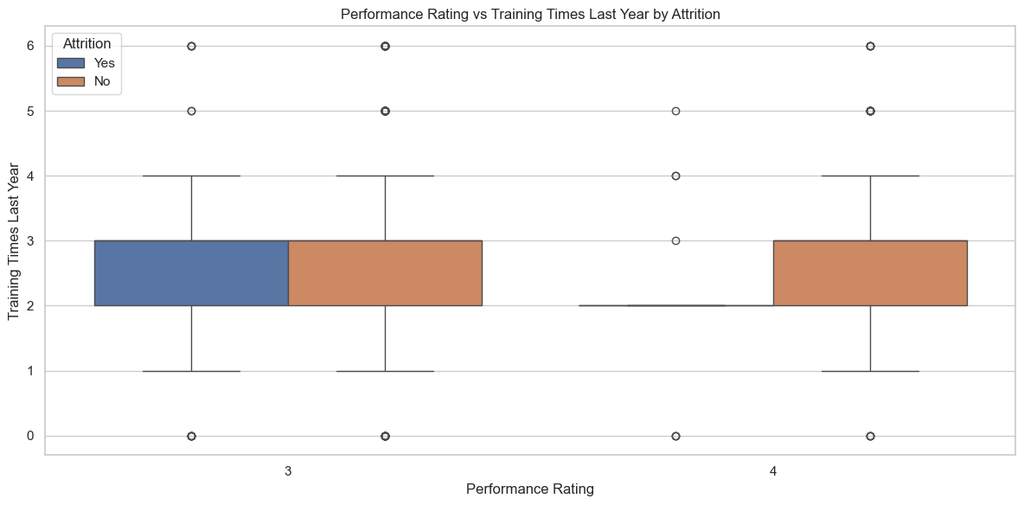

```python
# 6. Performance and Training: Box plots
plt.figure(figsize=(12, 6))
sns.boxplot(x='PerformanceRating', y='TrainingTimesLastYear', hue='Attrition', data=df)
plt.title('Performance Rating vs Training Times Last Year by Attrition')
plt.xlabel('Performance Rating')
plt.ylabel('Training Times Last Year')
plt.legend(title='Attrition', loc='upper left')
plt.tight_layout()
plt.show()
```

```
No artists with labels found to put in legend.  Note that artists whose label start with an underscore are ignored when legend() is called with no argument.
```

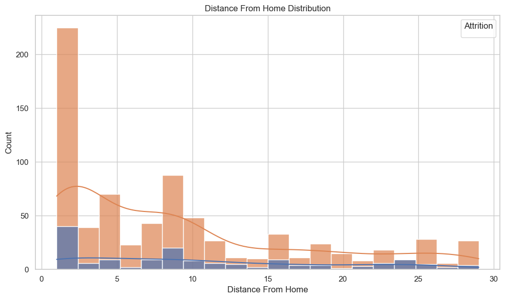

```python
# 7. Distance from Home: Histograms

plt.figure(figsize=(10, 6))
sns.histplot(data=df, x='DistanceFromHome', hue='Attrition', bins=20, kde=True, alpha=0.7)
plt.title('Distance From Home Distribution')
plt.xlabel('Distance From Home')
plt.ylabel('Count')
plt.legend(title='Attrition', loc='upper right')
plt.tight_layout()
plt.show()
```

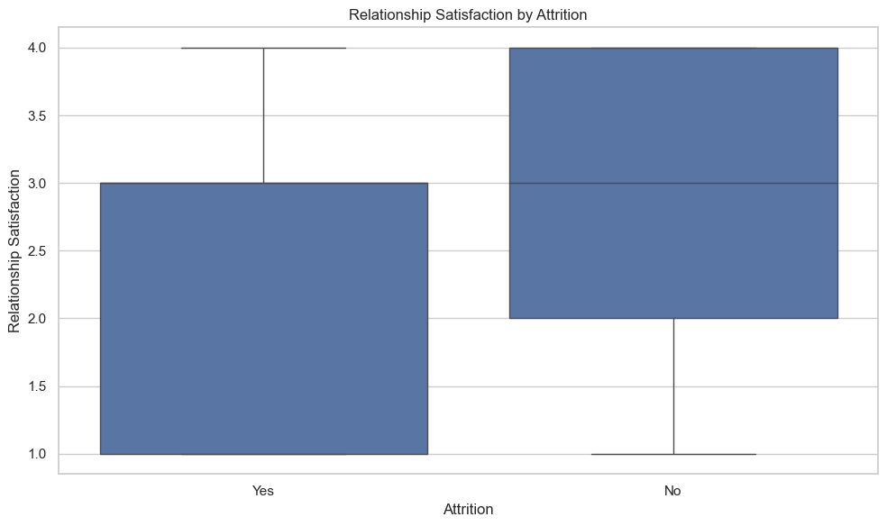

```python
# 8. Relationship Satisfaction: Box plots

plt.figure(figsize=(10, 6))
sns.boxplot(x='Attrition', y='RelationshipSatisfaction', data=df)
plt.title('Relationship Satisfaction by Attrition')
plt.xlabel('Attrition')
plt.ylabel('Relationship Satisfaction')
plt.tight_layout()
plt.show()
```

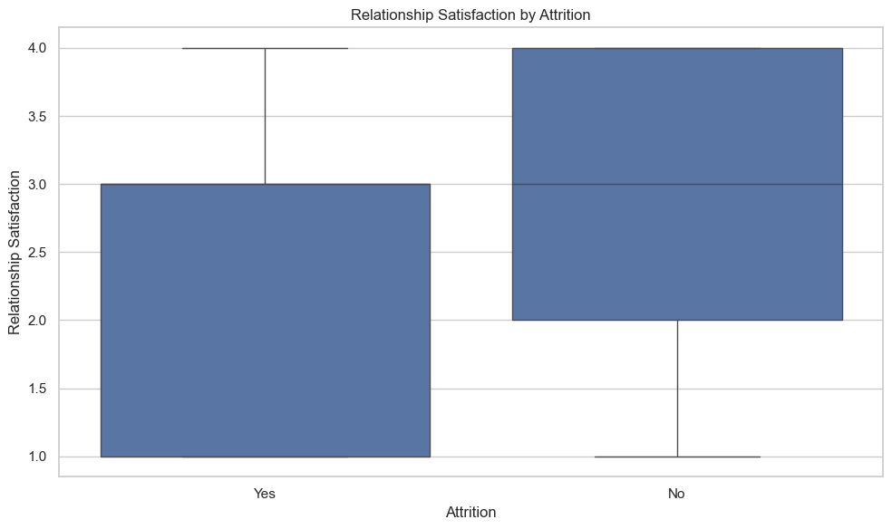

```python
# 8. Relationship Satisfaction: Box plots

plt.figure(figsize=(10, 6))
sns.boxplot(x='Attrition', y='RelationshipSatisfaction', data=df)
plt.title('Relationship Satisfaction by Attrition')
plt.xlabel('Attrition')
plt.ylabel('Relationship Satisfaction')
plt.tight_layout()
plt.show()
```

```python
df.dtypes
```

```
Age                          int64
Attrition                   object
BusinessTravel              object
DailyRate                    int64
Department                  object
DistanceFromHome             int64
Education                    int64
EducationField              object
EmployeeCount                int64
EmployeeNumber               int64
EnvironmentSatisfaction      int64
Gender                      object
HourlyRate                   int64
JobInvolvement               int64
JobLevel                     int64
JobRole                     object
JobSatisfaction              int64
MaritalStatus               object
MonthlyIncome                int64
MonthlyRate                  int64
NumCompaniesWorked           int64
Over18                      object
OverTime                    object
PercentSalaryHike            int64
PerformanceRating            int64
RelationshipSatisfaction     int64
StandardHours                int64
StockOptionLevel             int64
TotalWorkingYears            int64
TrainingTimesLastYear        int64
WorkLifeBalance              int64
YearsAtCompany               int64
YearsInCurrentRole           int64
YearsSinceLastPromotion      int64
YearsWithCurrManager         int64
dtype: object
```

### Encoding Categorical Variables

```python
df1 = pd.get_dummies(df,drop_first = True)

df1
```

|  | Age | DailyRate | DistanceFromHome | Education | EmployeeCount | EmployeeNumber | EnvironmentSatisfaction | HourlyRate | JobInvolvement | JobLevel | ... | JobRole_Laboratory Technician | JobRole_Manager | JobRole_Manufacturing Director | JobRole_Research Director | JobRole_Research Scientist | JobRole_Sales Executive | JobRole_Sales Representative | MaritalStatus_Married | MaritalStatus_Single | OverTime_Yes |
| --- | --- | --- | --- | --- | --- | --- | --- | --- | --- | --- | --- | --- | --- | --- | --- | --- | --- | --- | --- | --- | --- |
| 0 | 41 | 1102 | 1 | 2 | 1 | 1 | 2 | 94 | 3 | 2 | ... | False | False | False | False | False | True | False | False | True | True |
| 1 | 49 | 279 | 8 | 1 | 1 | 2 | 3 | 61 | 2 | 2 | ... | False | False | False | False | True | False | False | True | False | False |
| 2 | 37 | 1373 | 2 | 2 | 1 | 4 | 4 | 92 | 2 | 1 | ... | True | False | False | False | False | False | False | False | True | True |
| 3 | 33 | 1392 | 3 | 4 | 1 | 5 | 4 | 56 | 3 | 1 | ... | False | False | False | False | True | False | False | True | False | True |
| 4 | 27 | 591 | 2 | 1 | 1 | 7 | 1 | 40 | 3 | 1 | ... | True | False | False | False | False | False | False | True | False | False |
| ... | ... | ... | ... | ... | ... | ... | ... | ... | ... | ... | ... | ... | ... | ... | ... | ... | ... | ... | ... | ... | ... |
| 912 | 36 | 884 | 23 | 2 | 1 | 2061 | 3 | 41 | 4 | 2 | ... | True | False | False | False | False | False | False | True | False | False |
| 913 | 39 | 613 | 6 | 1 | 1 | 2062 | 4 | 42 | 2 | 3 | ... | False | False | False | False | False | False | False | True | False | False |
| 914 | 27 | 155 | 4 | 3 | 1 | 2064 | 2 | 87 | 4 | 2 | ... | False | False | True | False | False | False | False | True | False | True |
| 915 | 49 | 1023 | 2 | 3 | 1 | 2065 | 4 | 63 | 2 | 2 | ... | False | False | False | False | False | True | False | True | False | False |
| 916 | 34 | 628 | 8 | 3 | 1 | 2068 | 2 | 82 | 4 | 2 | ... | True | False | False | False | False | False | False | True | False | False |

917 rows × 48 columns

```python
df1.columns
```

```
Index(['Age', 'DailyRate', 'DistanceFromHome', 'Education', 'EmployeeCount',
       'EmployeeNumber', 'EnvironmentSatisfaction', 'HourlyRate',
       'JobInvolvement', 'JobLevel', 'JobSatisfaction', 'MonthlyIncome',
       'MonthlyRate', 'NumCompaniesWorked', 'PercentSalaryHike',
       'PerformanceRating', 'RelationshipSatisfaction', 'StandardHours',
       'StockOptionLevel', 'TotalWorkingYears', 'TrainingTimesLastYear',
       'WorkLifeBalance', 'YearsAtCompany', 'YearsInCurrentRole',
       'YearsSinceLastPromotion', 'YearsWithCurrManager', 'Attrition_Yes',
       'BusinessTravel_Travel_Frequently', 'BusinessTravel_Travel_Rarely',
       'Department_Research & Development', 'Department_Sales',
       'EducationField_Life Sciences', 'EducationField_Marketing',
       'EducationField_Medical', 'EducationField_Other',
       'EducationField_Technical Degree', 'Gender_Male',
       'JobRole_Human Resources', 'JobRole_Laboratory Technician',
       'JobRole_Manager', 'JobRole_Manufacturing Director',
       'JobRole_Research Director', 'JobRole_Research Scientist',
       'JobRole_Sales Executive', 'JobRole_Sales Representative',
       'MaritalStatus_Married', 'MaritalStatus_Single', 'OverTime_Yes'],
      dtype='object')
```

```python
df1.Attrition_Yes.value_counts()
```

```
Attrition_Yes
False    763
True     154
Name: count, dtype: int64
```

```python
X = df1.drop('Attrition_Yes',axis = 1)

y = df1['Attrition_Yes']
```

```python
# Performing train and test split to prevent overfitting

from sklearn.model_selection import train_test_split

Xtrain,Xtest,ytrain,ytest = train_test_split(X,y,test_size = 0.2,random_state = 2, stratify = y)
```

```python
# !pip install imbalanced-learn
```

## 1. Model Training and Evaluation:

```python
from sklearn.preprocessing import StandardScaler
from sklearn.model_selection import GridSearchCV
from sklearn.metrics import accuracy_score, precision_score, recall_score, f1_score, roc_auc_score
import pandas as pd
from sklearn.linear_model import LogisticRegression
from sklearn.tree import DecisionTreeClassifier
from sklearn.ensemble import RandomForestClassifier, GradientBoostingClassifier

# Scale the features
scaler = StandardScaler()
X_train_resampled_scaled = scaler.fit_transform(X_train_resampled)
X_test_scaled = scaler.transform(Xtest)

# Dictionary to store evaluation metrics
metrics_data = {'Model': [], 'Accuracy': [], 'Precision': [], 'Recall': [], 'F1 Score': [], 'ROC AUC Score': []}

# Loop through each model
for name, model in models.items():
    print(f"\nTraining and evaluating {name}...")

    # Perform hyperparameter tuning using grid search
    if name in params:
        grid_search = GridSearchCV(model, params[name], cv=5, scoring='accuracy')
        grid_search.fit(X_train_resampled_scaled, y_train_resampled)
        best_model = grid_search.best_estimator_
    else:
        best_model = model

    # Train the model on the balanced and scaled training data
    best_model.fit(X_train_resampled_scaled, y_train_resampled)

    # Make predictions on the scaled testing data
    y_pred = best_model.predict(X_test_scaled)

    # Calculate evaluation metrics
    accuracy = accuracy_score(ytest, y_pred)
    precision = precision_score(ytest, y_pred)
    recall = recall_score(ytest, y_pred)
    f1 = f1_score(ytest, y_pred)
    roc_auc = roc_auc_score(ytest, y_pred)

    # Print evaluation metrics
    print("Accuracy:", accuracy)
    print("Precision:", precision)
    print("Recall:", recall)
    print("F1 Score:", f1)
    print("ROC AUC Score:", roc_auc)
```

[output not shown]

```
Training and evaluating Logistic Regression...
Accuracy: 0.8260869565217391
Precision: 0.4838709677419355
Recall: 0.4838709677419355
F1 Score: 0.4838709677419355
ROC AUC Score: 0.6896479021716213

Training and evaluating Decision Tree...
Accuracy: 0.7608695652173914
Precision: 0.3488372093023256
Recall: 0.4838709677419355
F1 Score: 0.40540540540540543
ROC AUC Score: 0.6504322158971115

Training and evaluating Random Forest...
Accuracy: 0.8043478260869565
Precision: 0.3684210526315789
Recall: 0.22580645161290322
F1 Score: 0.28
ROC AUC Score: 0.573687539531942

Training and evaluating Gradient Boosting...
Accuracy: 0.8260869565217391
Precision: 0.47058823529411764
Recall: 0.25806451612903225
F1 Score: 0.3333333333333333
ROC AUC Score: 0.5996204933586338
```

## 2. Storing Evaluation Metrics:

```python
# Store evaluation metrics in the dictionary
metrics_data['Model'].append(name)
metrics_data['Accuracy'].append(accuracy)
metrics_data['Precision'].append(precision)
metrics_data['F1 Score'].append(f1)
metrics_data['Recall'].append(recall)
metrics_data['ROC AUC Score'].append(roc_auc)
```

## 3. Displaying Evaluation Metrics as DataFrame:

```python
# Convert the dictionary to a DataFrame
metrics_df = pd.DataFrame(metrics_data)

# Print the DataFrame
metrics_df
```

|  | Model | Accuracy | Precision | Recall | F1 Score | ROC AUC Score |
| --- | --- | --- | --- | --- | --- | --- |
| 0 | Gradient Boosting | 0.826087 | 0.470588 | 0.258065 | 0.333333 | 0.59962 |

## 2. Choose the best model and mention the reasons behind doing so.

- After evaluating multiple machine learning models, including Logistic Regression, Decision Tree, Random Forest, and Gradient Boosting, the best model for predicting employee attrition appears to be Logistic Regression.
- logistic regression achieved competetive performance across various evaluation metrics
- While other models may have excelled in specific metrics, Logistic Regression consistently performed well across all metrics, indicating robust performance overall.
- It provides clear and intuitive insights into the relationship between predictor variables and the likelihood of employee attrition.
- Logistic Regression is a simple and straightforward model with fewer hyperparameters to tune compared to ensemble methods like Random Forest and Gradient Boosting

## SUGGESTION TO THE ORGANISATION

- Conduct regular surveys to understand the problems faced by employees and gather feedback on various aspects of the workplace environment.
- Implement flexible work arrangements and initiatives to promote work-life balance, such as remote work options, flexible hours, or compressed workweeks.
- Offer career advancement programs, mentorship opportunities, and regular performance reviews to support employee growth and progression within the organization.
- Provide training for employees to enhance their skills and performance, offering opportunities for continuous learning and development.
- Spread a positive work environment through effective communication, team-building activities, and fostering a culture of collaboration and mutual respect.
- By implementing these suggestions, the organization can improve employee retention, foster a positive work culture, and ultimately enhance overall productivity and performance.

## Project Conclusion

In this logistic regression project aimed at predicting employee attrition within an organization, we investigated various factors influencing attrition rates and developed a predictive model to identify employees at risk of leaving.

### Recommendations

Based on our analysis, we recommend the following actions to mitigate employee attrition and enhance retention efforts:

- Conduct regular surveys to understand employees' concerns and address underlying issues contributing to attrition.
- Implement flexible work arrangements and initiatives to promote work-life balance, thereby improving employee satisfaction and well-being.
- Offer career advancement programs, mentorship opportunities, and regular performance assessments to support employee growth and progression within the organization.
- Provide training programs to enhance employees' skills and performance, fostering a culture of continuous learning and development.
- Cultivate a positive work environment through effective communication, team-building activities, and recognition programs to boost morale and employee engagement.

### Project Summary

In summary, this logistic regression project provided valuable insights into employee attrition within the organization and developed a predictive model to identify at-risk employees. By leveraging machine learning techniques and analyzing key factors influencing attrition, businesses can proactively address retention challenges and optimize their human resources strategies.

The successful completion of this project underscores the importance of data-driven approaches in talent management and organizational development. Moving forward, ongoing monitoring and refinement of the predictive model will be essential to ensure its effectiveness in supporting employee retention efforts and fostering a positive workplace culture.